# Assignment 3

Santiago Rattenbach, Àngel Jiménez, Albert Salom

21/11/2024

## The Data

```r
data <- read.csv("./loan_data.csv", header=TRUE, stringsAsFactors=TRUE)
str(data)
```

```
## 'data.frame':    45000 obs. of  14 variables:
##  $ person_age                    : num  22 21 25 23 24 21 26 24 24 21 ...
##  $ person_gender                 : Factor w/ 2 levels "female","male": 1 1 1 1 2 1 1 1 1 1 ...
##  $ person_education              : Factor w/ 5 levels "Associate","Bachelor",..: 5 4 4 2 5 4 2 4 1 4 ...
##  $ person_income                 : num  71948 12282 12438 79753 66135 ...
##  $ person_emp_exp                : int  0 0 3 0 1 0 1 5 3 0 ...
##  $ person_home_ownership         : Factor w/ 4 levels "MORTGAGE","OTHER",..: 4 3 1 4 4 3 4 4 4 3 ...
##  $ loan_amnt                     : num  35000 1000 5500 35000 35000 2500 35000 35000 35000 1600 ...
##  $ loan_intent                   : Factor w/ 6 levels "DEBTCONSOLIDATION",..: 5 2 4 4 4 6 2 4 5 6 ...
##  $ loan_int_rate                 : num  16 11.1 12.9 15.2 14.3 ...
##  $ loan_percent_income           : num  0.49 0.08 0.44 0.44 0.53 0.19 0.37 0.37 0.35 0.13 ...
##  $ cb_person_cred_hist_length    : num  3 2 3 2 4 2 3 4 2 3 ...
##  $ credit_score                  : int  561 504 635 675 586 532 701 585 544 640 ...
##  $ previous_loan_defaults_on_file: Factor w/ 2 levels "No","Yes": 1 2 1 1 1 1 1 1 1 1 ...
##  $ loan_status                   : int  1 0 1 1 1 1 1 1 1 1 ...
```

### Independent Variables

As we can see, the dataset contains 45,000 observations and 14 variables. The variables are as follows:

1. **person age:** Age of the person (numeric)
2. **person gender:** Gender of the person (categorical: female, male)
3. **person education:** Highest education level (categorical: Associate, Bachelor, Doctorate, High School, Master)
4. **person income:** Annual income (numeric)
5. **person emp exp:** Years of employment experience (integer)
6. **person home ownership:** Home ownership status (categorical: MORTGAGE, OTHER, OWN, RENT)
7. **loan amnt:** Loan amount requested (numeric)
8. **loan intent:** Purpose of the loan (categorical: DEBTCONSOLIDATION, EDUCATION, HOME-IMPROVEMENT, MEDICAL, PERSONAL, VENTURE)
9. **loan int rate:** Loan interest rate (numeric)
10. **loan percent income:** Loan amount as a percentage of annual income (numeric)
11. **cb person cred hist length:** Length of credit history in years (numeric)
12. **credit score:** Credit score of the person (integer)
13. **previous loan defaults on file:** Indicator of previous loan defaults (categorical: No, Yes)

### Target Variable

- **loan_status**: The status of the loan (integer 1 = approved; 0 = rejected)

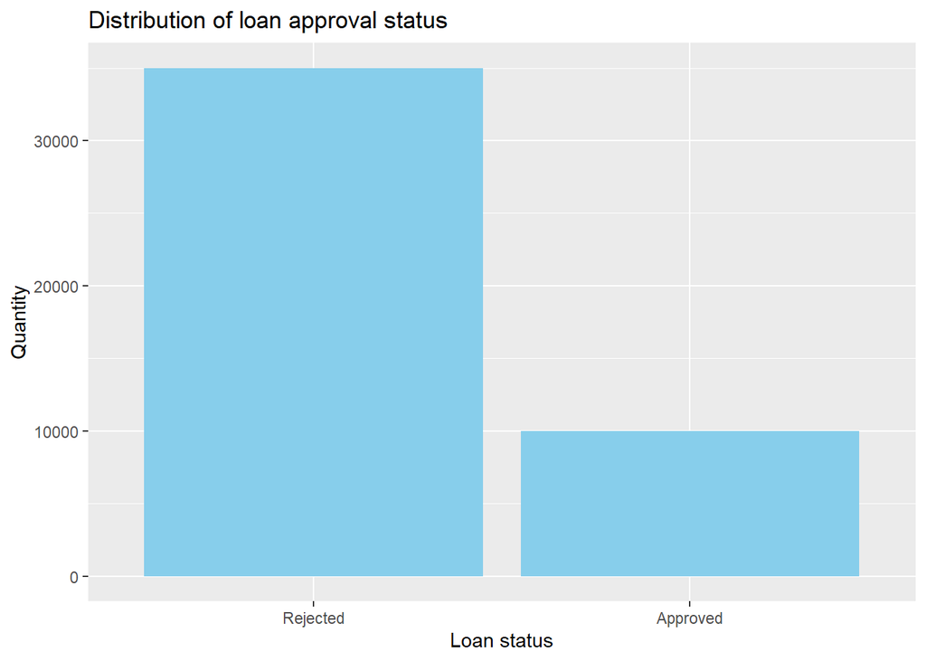

```r
# Create the bar plot
ggplot(data, aes(x = factor(loan_status, labels = c("Rejected", "Approved")))) +
  geom_bar(fill = "skyblue") +
  labs(title = "Distribution of loan approval status",
       x = "Loan status",
       y = "Quantity")
```

Most loans end up getting denied, we aim to understand why that is the case and build a model that predicts the outcome as much as possible.

### Summary of the Data

Before start training the model, it is important to analyze each of the independent variables to understand their values, distribution, and relationship with the target variable.

```r
summary(data)
```

```
##    person_age     person_gender     person_education person_income
##  Min.   : 20.00   female:20159   Associate  :12028   Min.   :   8000
##  1st Qu.: 24.00   male  :24841   Bachelor   :13399   1st Qu.:  47204
##  Median : 26.00                  Doctorate  :  621   Median :  67048
##  Mean   : 27.76                  High School:11972   Mean   :  80319
##  3rd Qu.: 30.00                  Master     : 6980   3rd Qu.:  95789
##  Max.   :144.00                                      Max.   :7200766
##  person_emp_exp   person_home_ownership   loan_amnt
##  Min.   :  0.00   MORTGAGE:18489        Min.   :  500
##  1st Qu.:  1.00   OTHER   :  117        1st Qu.: 5000
##  Median :  4.00   OWN     : 2951        Median : 8000
##  Mean   :  5.41   RENT    :23443        Mean   : 9583
##  3rd Qu.:  8.00                         3rd Qu.:12237
##  Max.   :125.00                         Max.   :35000
##             loan_intent   loan_int_rate   loan_percent_income
##  DEBTCONSOLIDATION:7145   Min.   : 5.42   Min.   :0.0000
##  EDUCATION        :9153   1st Qu.: 8.59   1st Qu.:0.0700
##  HOMEIMPROVEMENT  :4783   Median :11.01   Median :0.1200
##  MEDICAL          :8548   Mean   :11.01   Mean   :0.1397
##  PERSONAL         :7552   3rd Qu.:12.99   3rd Qu.:0.1900
##  VENTURE          :7819   Max.   :20.00   Max.   :0.6600
##  cb_person_cred_hist_length  credit_score   previous_loan_defaults_on_file
##  Min.   : 2.000             Min.   :390.0   No :22142
##  1st Qu.: 3.000             1st Qu.:601.0   Yes:22858
##  Median : 4.000             Median :640.0
##  Mean   : 5.867             Mean   :632.6
##  3rd Qu.: 8.000             3rd Qu.:670.0
##  Max.   :30.000             Max.   :850.0
##   loan_status
##  Min.   :0.0000
##  1st Qu.:0.0000
##  Median :0.0000
##  Mean   :0.2222
##  3rd Qu.:0.0000
##  Max.   :1.0000
```

#### Numerical Variables

- **person_age:** This dataset includes adults, so the minimum age is 20 years. The mean is 27.76 years, meaning most of the samples in the dataset are from young people. On the other hand, we can see that there are very few samples for people over 50 years old. Therefore, we will remove observations with ages above 50 as we consider them outliers.

```r
data <- subset(data, person_age <= 50)
```

- **person_income:** This dataset ranges from annual values of $8,000 to $7,200,766. We will assume that samples with annual incomes above $250,000 would not face any difficulty obtaining a loan within the scope of this dataset.

```r
data <- subset(data, person_income < 250000)
```

```r
aux <- subset(data, loan_percent_income == 0)
head(aux)
```

```
##       person_age person_gender person_education person_income person_emp_exp
## 239           22          male      High School        220518              0
## 16927         22          male      High School        220715              0
## 29189         41          male      High School        241503             20
##       person_home_ownership loan_amnt loan_intent loan_int_rate
## 239                MORTGAGE      1000   EDUCATION         11.01
## 16927              MORTGAGE      1000   EDUCATION         11.01
## 29189              MORTGAGE      1000     VENTURE         10.38
##       loan_percent_income cb_person_cred_hist_length credit_score
## 239                     0                          2          551
## 16927                   0                          2          577
## 29189                   0                         13          611
##       previous_loan_defaults_on_file loan_status
## 239                              Yes           0
## 16927                             No           0
## 29189                             No           0
```

We see that there are 3 samples with a loan percentage over annual income of 0%. This is impossible because if the percentage is 0%, the loan amount would be $0. Therefore, we will proceed to remove them.

```r
data <- subset(data, loan_percent_income != 0)
```

- **cb_person_cred_hist_length**: The length of credit history ranges from 2 to 30 years. There don’t seem to be any outliers.
- **credit_score**: The credit score ranges from 390 to 850. There don’t seem to be any outliers.

Let’s see how the dataset looks after removing the outliers:

```r
summary(data)
```

```
##    person_age    person_gender     person_education person_income
##  Min.   :20.00   female:19804   Associate  :11761   Min.   :  8000
##  1st Qu.:24.00   male  :24305   Bachelor   :13175   1st Qu.: 46875
##  Median :26.00                  Doctorate  :  593   Median : 66845
##  Mean   :27.49                  High School:11714   Mean   : 75506
##  3rd Qu.:30.00                  Master     : 6866   3rd Qu.: 94189
##  Max.   :50.00                                      Max.   :249925
##  person_emp_exp   person_home_ownership   loan_amnt
##  Min.   : 0.000   MORTGAGE:17936        Min.   :  500
##  1st Qu.: 1.000   OTHER   :  114        1st Qu.: 5000
##  Median : 4.000   OWN     : 2896        Median : 8000
##  Mean   : 5.136   RENT    :23163        Mean   : 9480
##  3rd Qu.: 8.000                         3rd Qu.:12000
##  Max.   :32.000                         Max.   :35000
##             loan_intent   loan_int_rate   loan_percent_income
##  DEBTCONSOLIDATION:6999   Min.   : 5.42   Min.   :0.0100
##  EDUCATION        :9035   1st Qu.: 8.59   1st Qu.:0.0700
##  HOMEIMPROVEMENT  :4688   Median :11.01   Median :0.1200
##  MEDICAL          :8399   Mean   :10.99   Mean   :0.1409
##  PERSONAL         :7312   3rd Qu.:12.99   3rd Qu.:0.1900
##  VENTURE          :7676   Max.   :20.00   Max.   :0.6600
##  cb_person_cred_hist_length  credit_score   previous_loan_defaults_on_file
##  Min.   : 2.000             Min.   :390.0   No :21704
##  1st Qu.: 3.000             1st Qu.:601.0   Yes:22405
##  Median : 4.000             Median :639.0
##  Mean   : 5.708             Mean   :632.2
##  3rd Qu.: 8.000             3rd Qu.:669.0
##  Max.   :26.000             Max.   :768.0
##   loan_status
##  Min.   :0.0000
##  1st Qu.:0.0000
##  Median :0.0000
##  Mean   :0.2232
##  3rd Qu.:0.0000
##  Max.   :1.0000
```

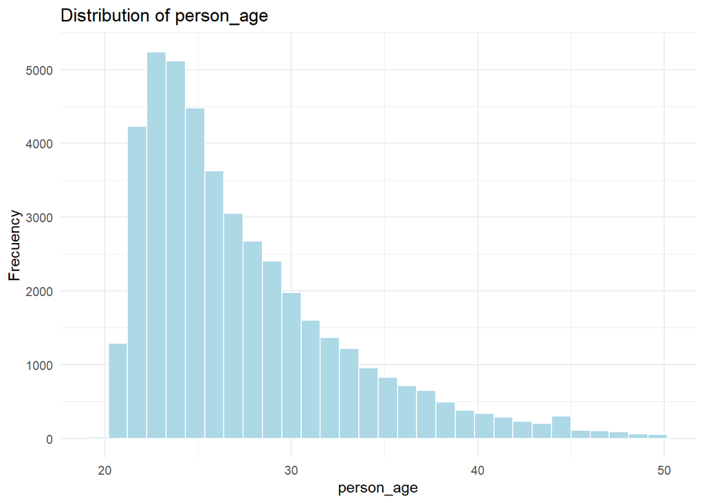

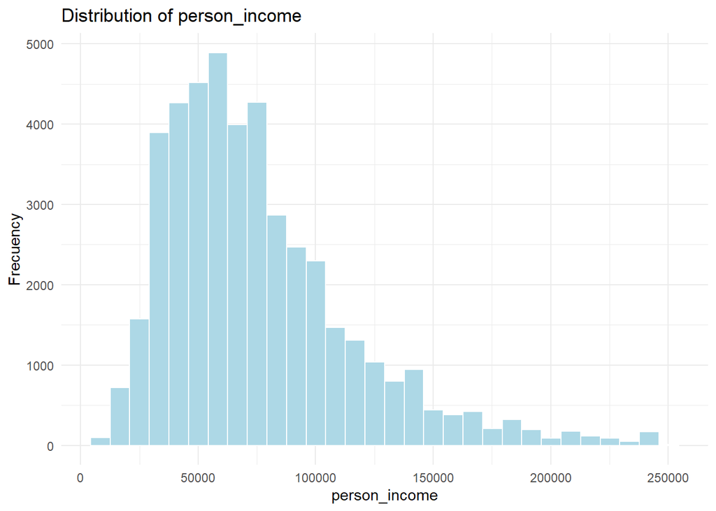

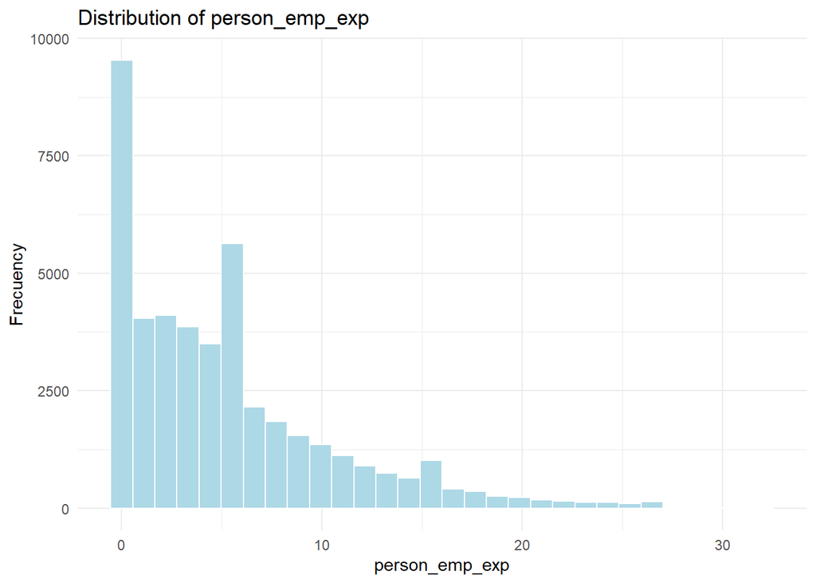

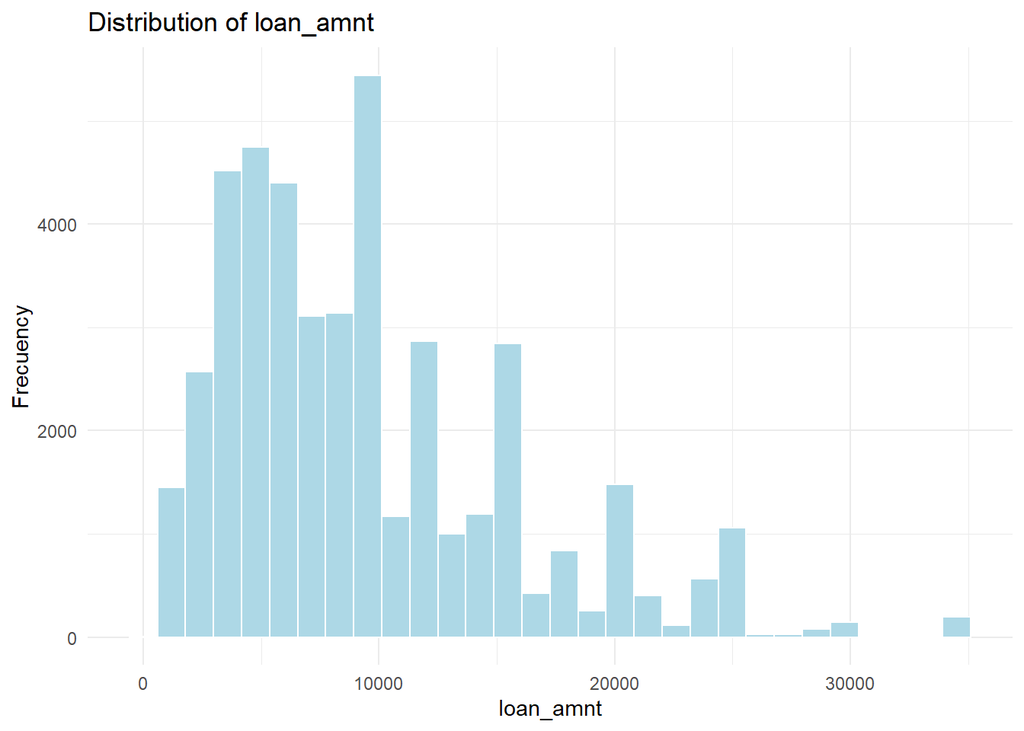

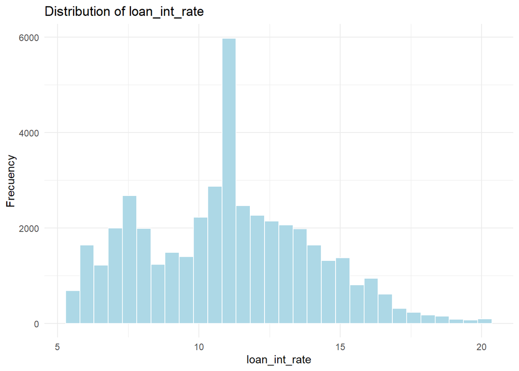

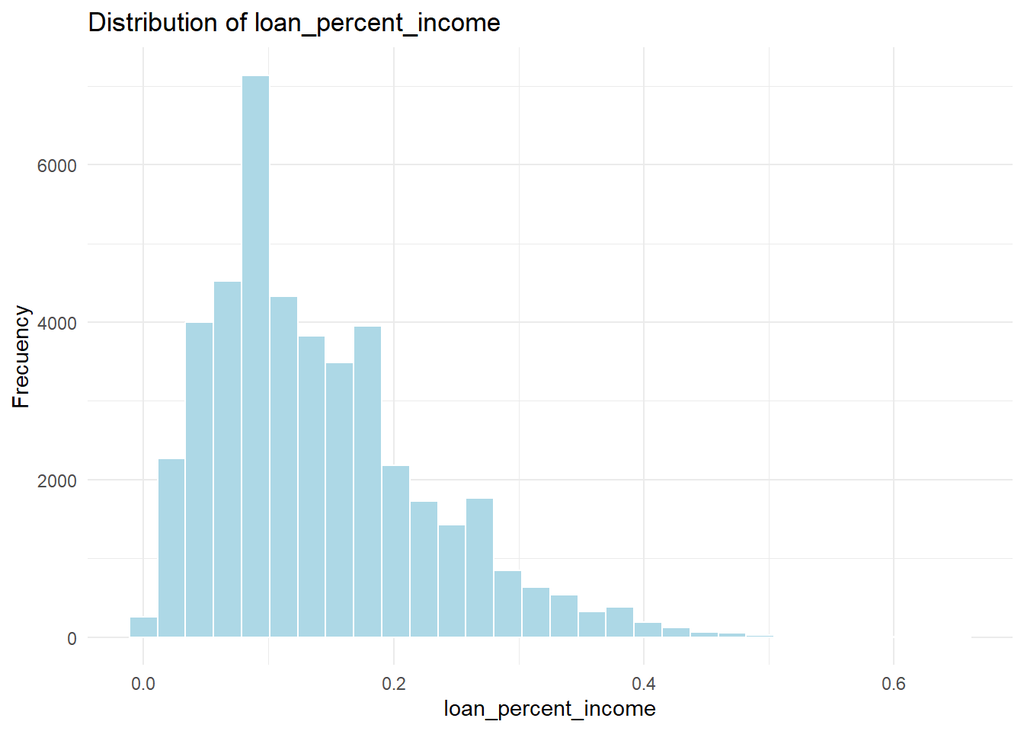

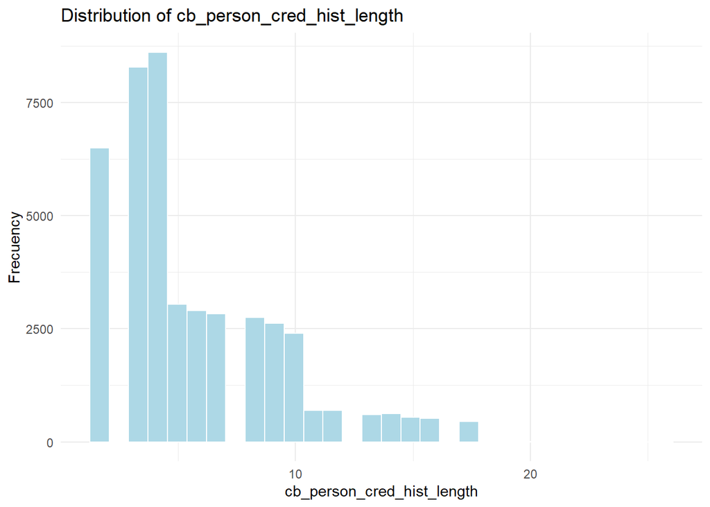

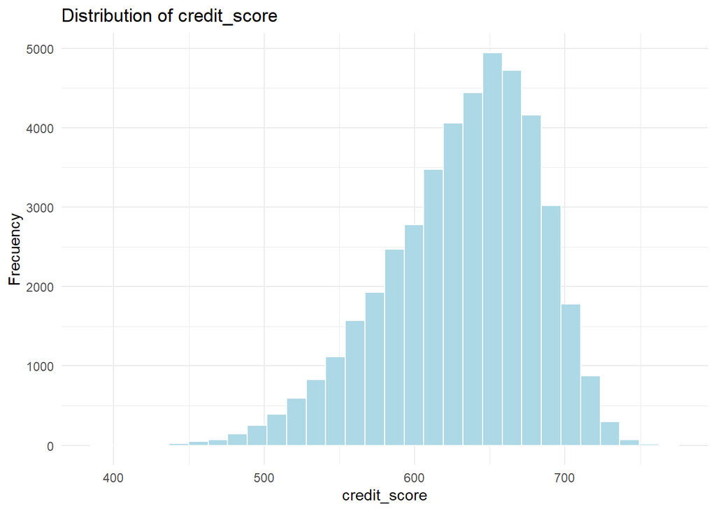

```r
# List of numerical variables:
numeric <- c('person_age', 'person_income', 'person_emp_exp', 'loan_amnt',
                    'loan_int_rate', 'loan_percent_income',
                    'cb_person_cred_hist_length', 'credit_score')


# Plot the distribution of each numerical variable:
for (n in numeric) {
  print(
    ggplot(data, aes(x = !!sym(n))) +
      geom_histogram(fill = "lightblue", color = "white", bins = 30) +
      labs(title = paste("Distribution of", n), x = n, y = "Frecuency") +
      theme_minimal()
  )
}
```

As we can see, except for the credit_score, most of the numerical variables do not follow a normal distribution and are right-skewed. Later, we’ll modify the values to make them follow a normal distribution.

#### Categorical

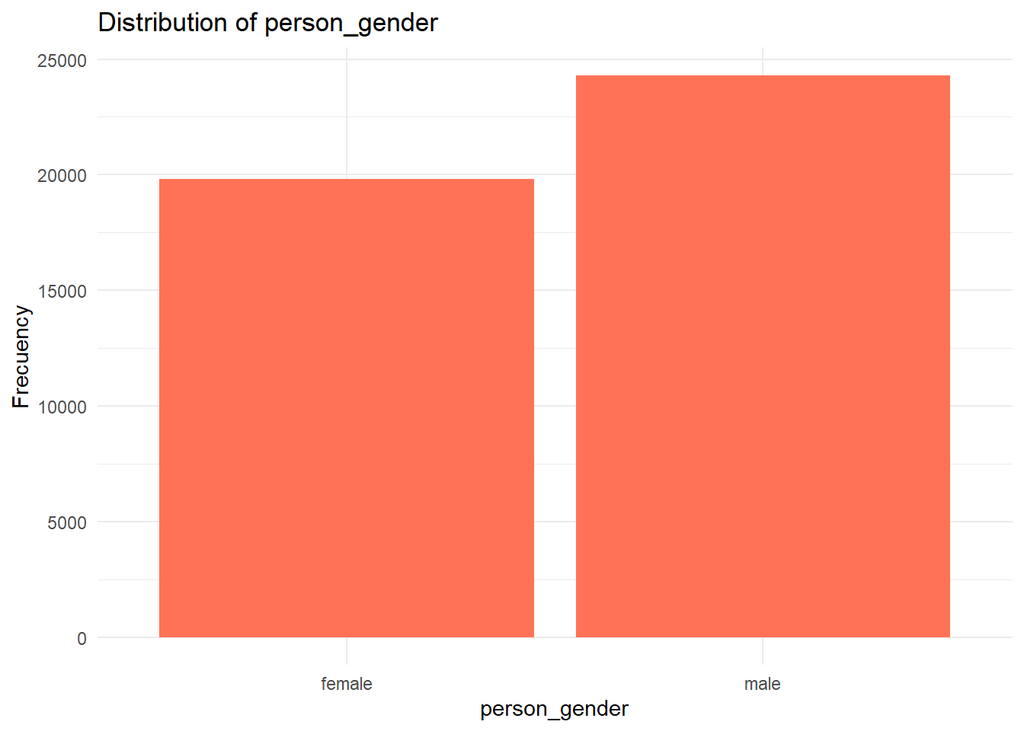

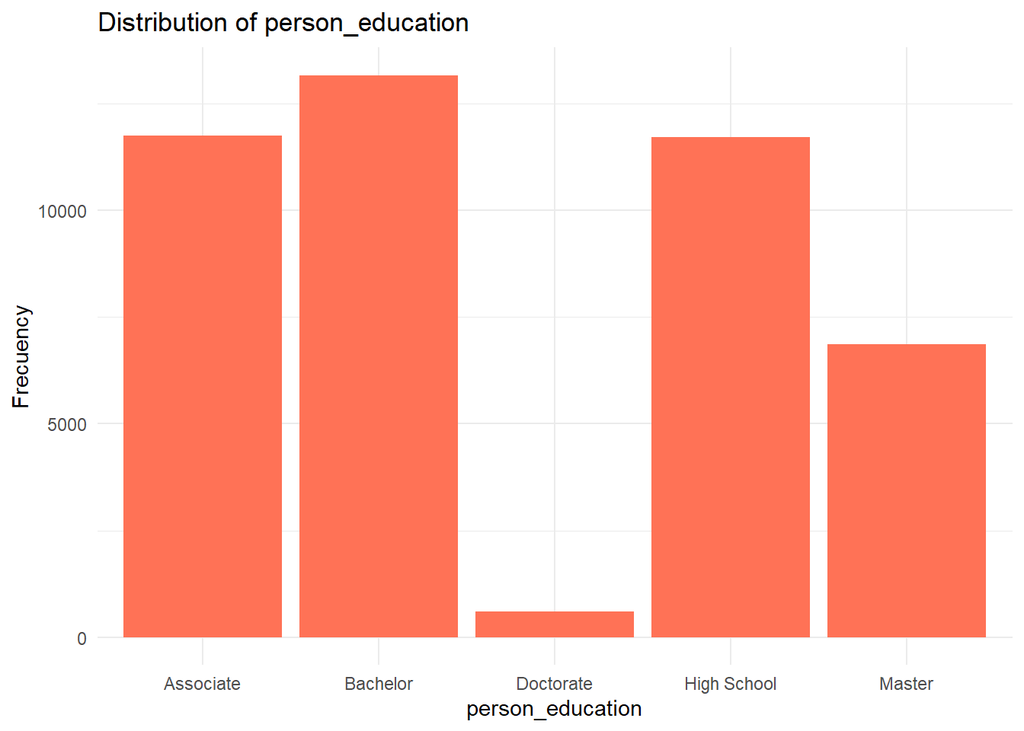

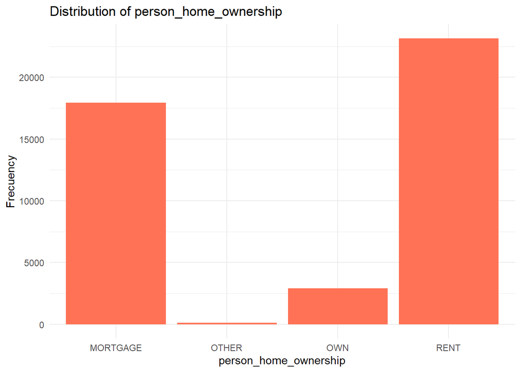

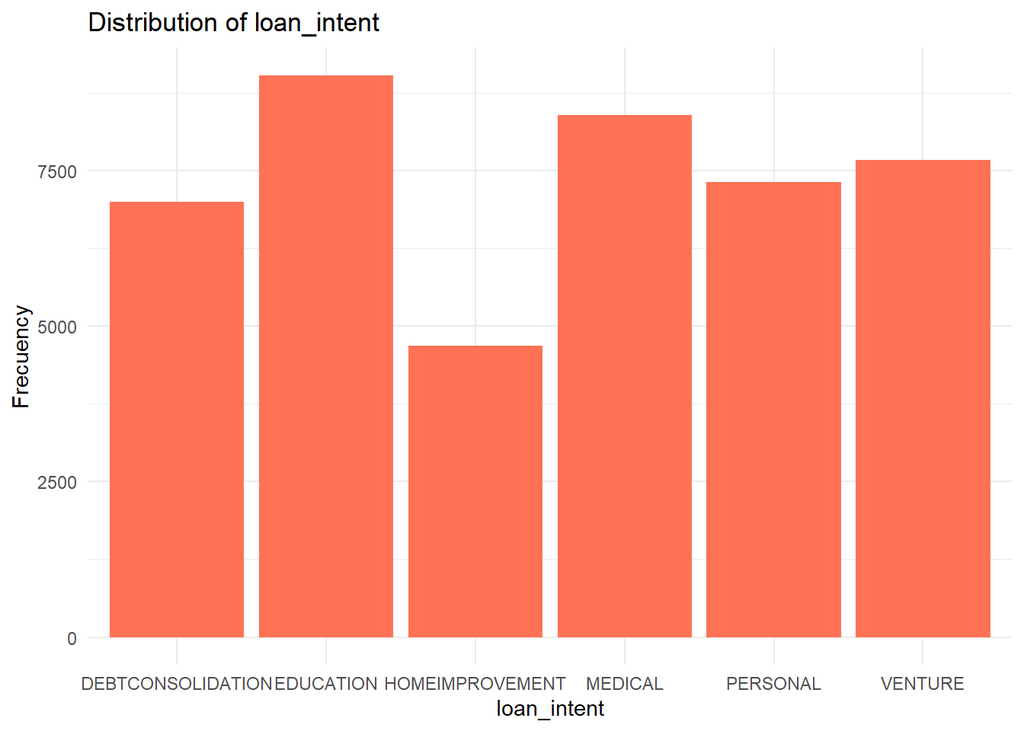

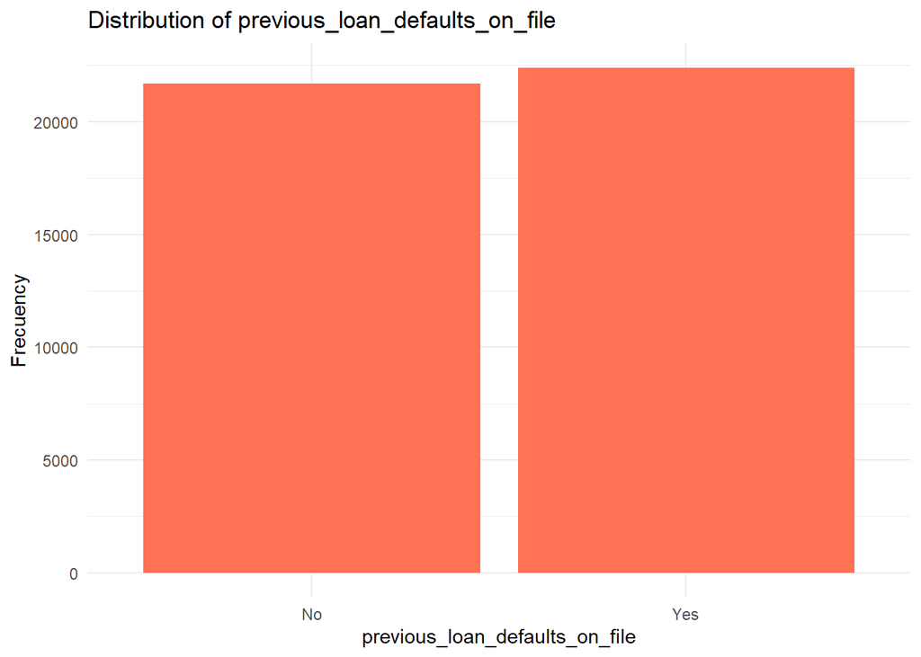

```r
# List of categorical variables:
categories <- c('person_gender', 'person_education', 'person_home_ownership', 'loan_intent', 'previous_loan_defaults_on_file')

for (var in categories) {
  print(
    ggplot(data, aes_string(x = var)) +
      geom_bar(fill = "coral1") +
      labs(title = paste("Distribution of", var), x = var, y = "Frecuency") +
      theme_minimal()
  )
}
```

### Data Correlations

#### Numerical Variables

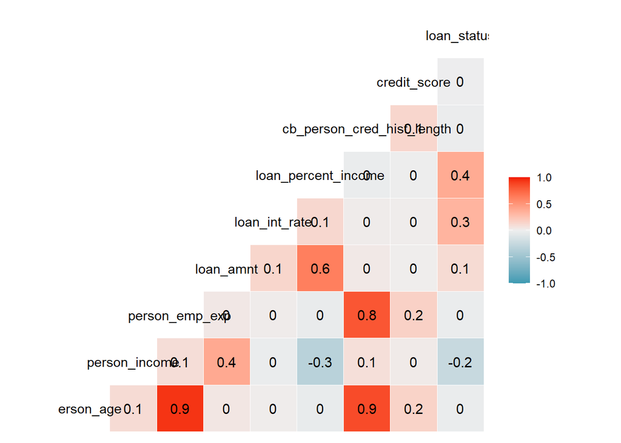

```r
numeric_Corr <- data[, c('person_age', 'person_income', 'person_emp_exp',
                        'loan_amnt', 'loan_int_rate', 'loan_percent_income',
                        'cb_person_cred_hist_length', 'credit_score', 'loan_status')]

ggcorr(numeric_Corr, label = TRUE)
```

As we can see, ‘credit_score’ has little influence, as its correlations with the other variables are virtually null and it has no correlation with the target variable. Therefore, we will proceed to remove it. On the other hand, ‘person_age’, ‘person_emp_exp’, and ‘cb_person_cred_hist_length’ have a very high correlation with each other, so we will remove ‘person_emp_exp’ and ‘cb_person_cred_hist_length’ to avoid multicollinearity.

```r
# Supression of the variables
data_Mod <- data[, -c(5, 11, 12)]

# Visualize the changes
names(data_Mod)
```

```
##  [1] "person_age"                     "person_gender"
##  [3] "person_education"               "person_income"
##  [5] "person_home_ownership"          "loan_amnt"
##  [7] "loan_intent"                    "loan_int_rate"
##  [9] "loan_percent_income"            "previous_loan_defaults_on_file"
## [11] "loan_status"
```

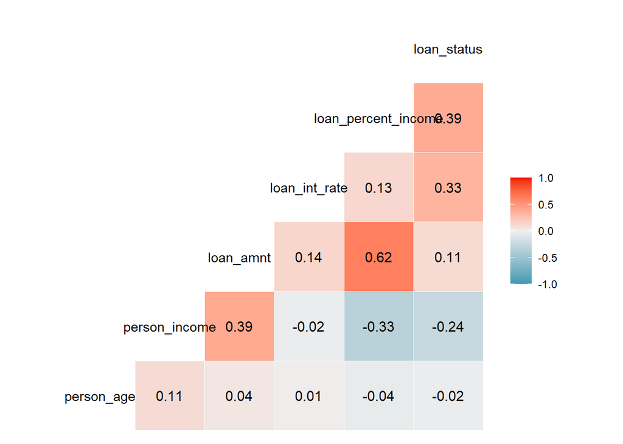

```r
# Compare the correlation matrix of the new dataset:
ggcorr(data_Mod, label = TRUE, label_round = 2)
```

Now we can see that the variable ‘person_age’ has little to no correlation with other variables or with the target variable. Therefore, it will not contribute to the model, so we will proceed to remove it.

```r
data_Mod <- data_Mod[, -c(1)]
```

### Bivariate Analysis

#### Numeric Variables

Comparing the loan status with the all numerical variables, we can see if there is any relationship between them.

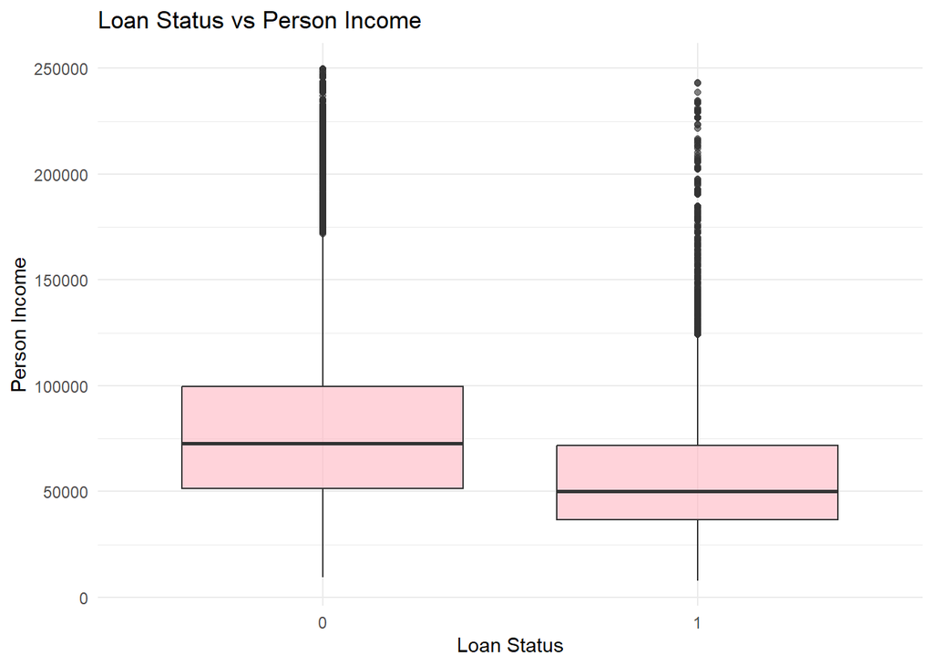

```r
p1 <- ggplot(data_Mod) + geom_boxplot(aes(x = factor(loan_status), y = person_income), fill = "#FFB6C1", alpha = 0.6) +
  theme(axis.title = element_text(size = 8.5)) +
  labs(title = "Loan Status vs Person Income", x = "Loan Status", y = "Person Income") +
  theme_minimal()

print(p1)
```

Loan approval is inversely proportional to the applicant’s income, higher incomes tend to have their loans rejected. This information doesn’t seem to make much sense to us, as we would think that loans taken by people with higher income should be both safer and more profitable, however that is not the case here.

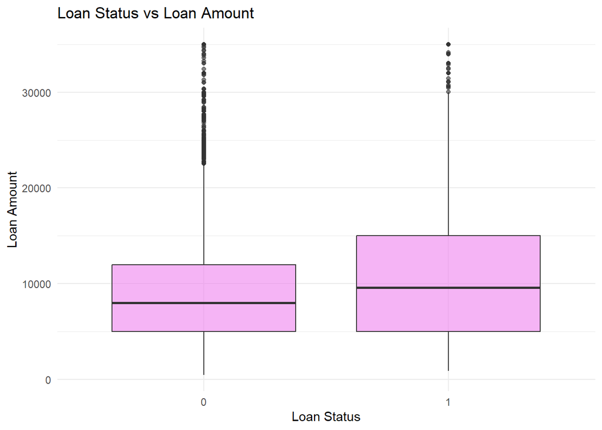

```r
p2 <- ggplot(data_Mod) + geom_boxplot(aes(x = factor(loan_status), y = loan_amnt), fill = "violet", alpha = 0.6) +
  theme(axis.title = element_text(size = 8.5)) +
  labs(title = "Loan Status vs Loan Amount", x = "Loan Status", y = "Loan Amount") +
  theme_minimal()

print(p2)
```

As we can see, those who have their loans approved tend to request higher loan amounts, that is, the higher the loan amount, the more likely it is to be approved. This makes sense as the bank would make more profit.

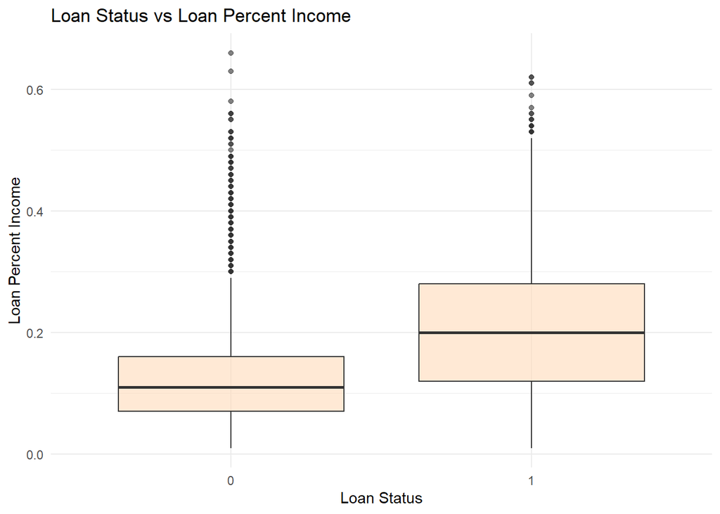

```r
p3 <- ggplot(data_Mod) + geom_boxplot(aes(x = factor(loan_status), y = loan_percent_income), fill = "#FFDAB9", alpha = 0.6) +
  theme(axis.title = element_text(size = 8.5)) +
  labs(title = "Loan Status vs Loan Percent Income", x = "Loan Status", y = "Loan Percent Income") +
  theme_minimal()

print(p3)
```

In this case, those who have a higher loan percentage over annual income are more likely to have their loans approved. This is probably because the bank makes more profit from these loans with more interest rate, even though they are riskier than those with a lower percentage.

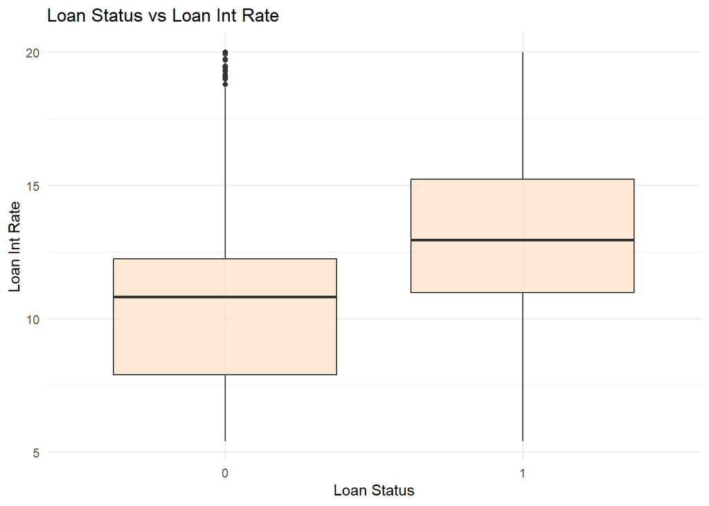

```r
p4 <- ggplot(data_Mod) + geom_boxplot(aes(x = factor(loan_status), y = loan_int_rate), fill = "#FFDAB9", alpha = 0.6) +
  theme(axis.title = element_text(size = 8.5)) +
  labs(title = "Loan Status vs Loan Int Rate", x = "Loan Status", y = "Loan Int Rate") +
  theme_minimal()

print(p4)
```

#### Categorical Variables

Comparing the loan status with every categorical variable, we can see if there is any relationship between them.

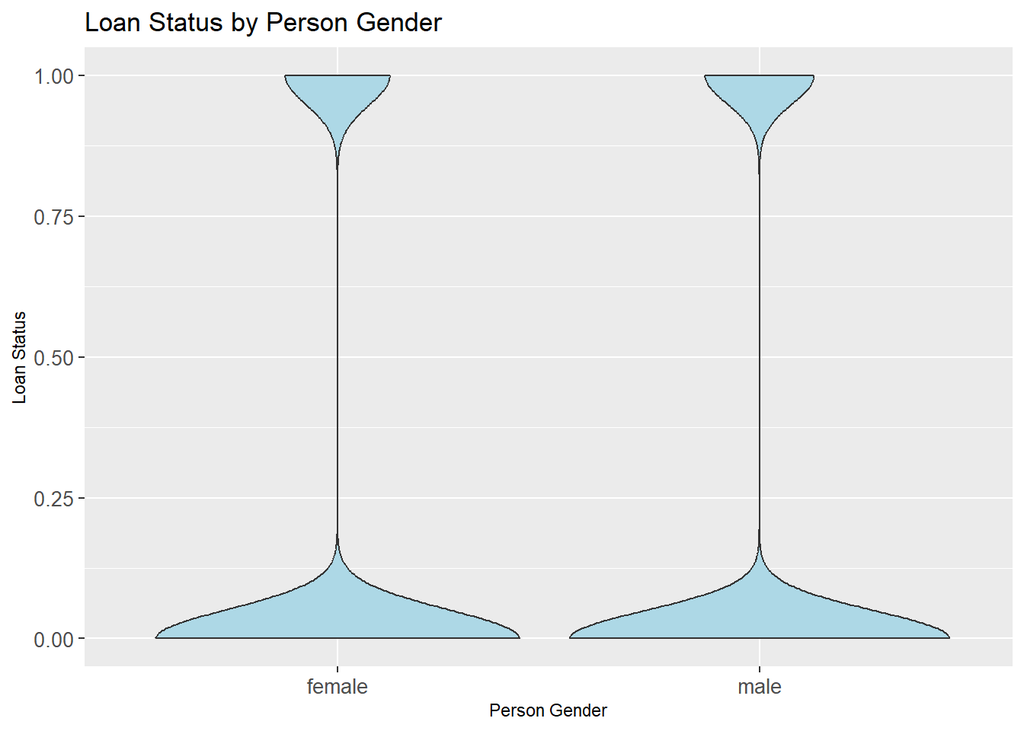

```r
p1 <- ggplot(data_Mod) +
  geom_violin(aes(x = person_gender, y = loan_status), fill = "lightblue") +
  theme(axis.text = element_text(size = 10),
        axis.title = element_text(size = 8.5)) +
  labs(title = "Loan Status by Person Gender", x = "Person Gender", y = "Loan Status")

print(p1)
```

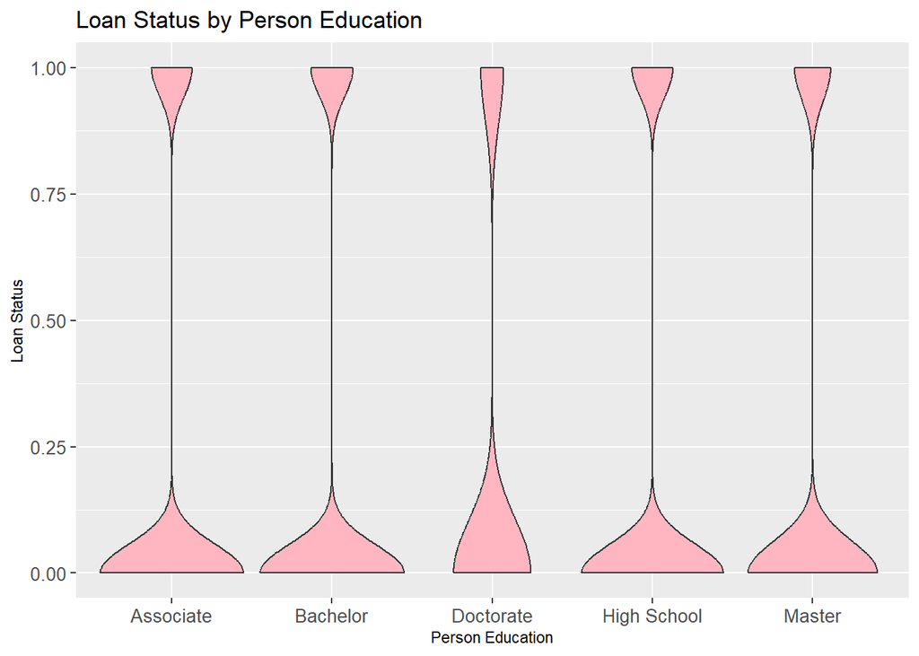

```r
p2 <- ggplot(data_Mod) +
  geom_violin(aes(x = person_education, y = loan_status), fill = "lightpink") +
  theme(axis.text = element_text(size = 10),
        axis.title = element_text(size = 8.5)) +
  labs(title = "Loan Status by Person Education", x = "Person Education", y = "Loan Status")

print(p2)
```

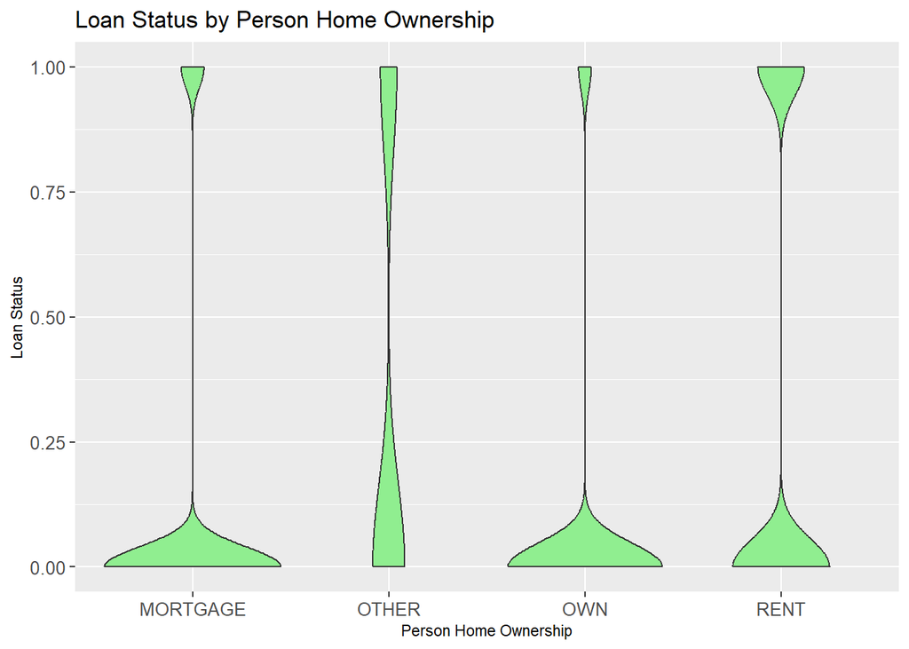

```r
p3 <- ggplot(data_Mod) +
  geom_violin(aes(x = person_home_ownership, y = loan_status), fill = "lightgreen") +
  theme(axis.text = element_text(size = 10),
        axis.title = element_text(size = 8.5)) +
  labs(title = "Loan Status by Person Home Ownership", x = "Person Home Ownership", y = "Loan Status")

print(p3)
```

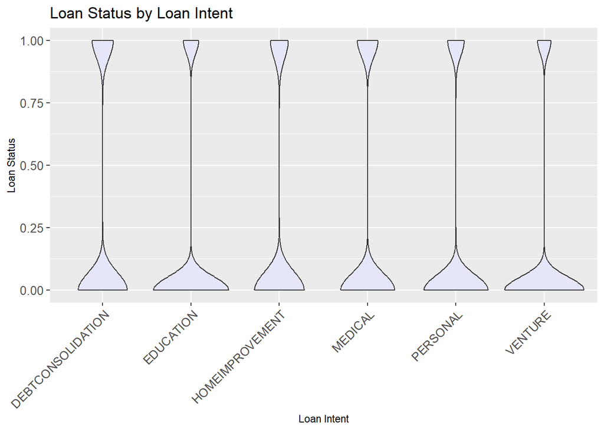

```r
p4 <- ggplot(data_Mod) +
  geom_violin(aes(x = loan_intent, y = loan_status), fill = "lavender") +
  theme(axis.text.x = element_text(angle = 45, hjust = 1),
        axis.text = element_text(size = 10),
        axis.title = element_text(size = 8.5)) +
  labs(title = "Loan Status by Loan Intent", x = "Loan Intent", y = "Loan Status")

print(p4)
```

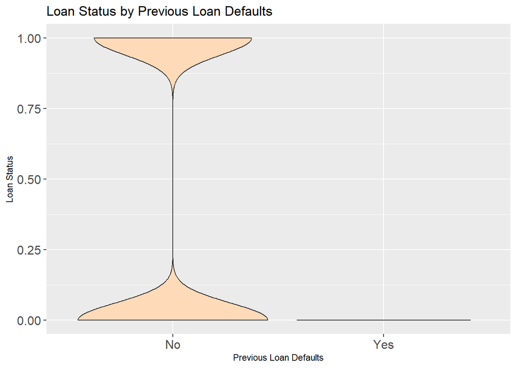

```r
p5 <- ggplot(data_Mod) +
  geom_violin(aes(x = previous_loan_defaults_on_file, y = loan_status), fill = "peachpuff") +
  theme(axis.text = element_text(size = 12),
        axis.title = element_text(size = 8.5)) +
  labs(title = "Loan Status by Previous Loan Defaults", x = "Previous Loan Defaults", y = "Loan Status")

print(p5)
```

It can be seen that the variable ‘previous_loan_defaults_on_file’ is key to predicting the loan status, as applicants who have had previous loan defaults are always rejected. On the other hand, the rest of the attributes do not seem to have a significant impact on the loan status (at least not easily seen via this plots) regardless of their value, as all of their profiles are accepted around 25% of the times.

### Missing Value Analysis

To find missing values in the dataset, we can use the `is.na()` function in R.

```r
colSums(is.na(data_Mod))
```

```
##                  person_gender               person_education
##                              0                              0
##                  person_income          person_home_ownership
##                              0                              0
##                      loan_amnt                    loan_intent
##                              0                              0
##                  loan_int_rate            loan_percent_income
##                              0                              0
## previous_loan_defaults_on_file                    loan_status
##                              0                              0
```

As we can see, there are no missing values in the dataset, so we can proceed to the next stage.

### Key Features

As we have already seen with the violin plots, the ‘previous_loan_defaults_on_file’ variable is key to predicting the loan status, as applicants who have had previous loan defaults are always rejected.

Analyzing the correlation between the variables, it is observed that person_income, loan_int_rate, loan_percent_income and, to a lesser extent, loan_amnt have a high correlation with the loan_status variable, therefore they are also important variables to consider.

### PreProcessing Data

#### Checking Normality (Skewness)

Now we will check the normality of the numerical variables to see if they follow a normal distribution. In case they do not, we will apply transformations to make them follow a normal distribution.

- **person_income**:

```r
skewness(data_Mod$person_income)
```

```
## [1] 1.313766
```

We get a skewness of 1.31, so we need to apply another transformation, to improve the distribution.

```r
skewness(log(data_Mod$person_income))
```

```
## [1] -0.179968
```

We see that by applying this logarithmic transformation, we improve the distribution of the ‘person_income’ variable, going from 1.31 to -0.18, which is a significant improvement.

- **loan_amnt**:

```r
skewness(data_Mod$loan_amnt)
```

```
## [1] 1.166657
```

We get a skewness of 1.17, so we need to apply a transformation to improve it.

```r
skewness(sqrt(data_Mod$loan_amnt))
```

```
## [1] 0.4060415
```

```r
skewness(log(data_Mod$loan_amnt))
```

```
## [1] -0.4435303
```

As we can see, both solve the skewness problem, but the square root transformation is more effective.

- **loan_int_rate**:

```r
skewness(data_Mod$loan_int_rate)
```

```
## [1] 0.2122018
```

We get a skewness of 0.21, so we do not need to apply any transformation.

- **loan_percent_income**:

```r
skewness(data_Mod$loan_percent_income)
```

```
## [1] 1.031219
```

We get a skewness of 1.03, so we need to apply another transformation.

```r
skewness(sqrt(data_Mod$loan_percent_income))
```

```
## [1] 0.2829467
```

```r
skewness(log(data_Mod$loan_percent_income))
```

```
## [1] -0.5841842
```

As we can see, both help improve the skewness problem, but the square root transformation is more effective and falls within the acceptable range.

#### Creation of a better skewed dataset

With all the transformations made, we proceed to create a new dataset with the transformed variables, as their distribution follows the normal distribution more closely:

```r
data_Transformed <- data_Mod

data_Transformed$person_income <- log(data_Mod$person_income)
data_Transformed$loan_amnt <- sqrt(data_Mod$loan_amnt)
data_Transformed$loan_percent_income <- sqrt(data_Mod$loan_percent_income)
```

## Model Building

### Sorting Variables

To better handle the data, we find it convenient to reorder the columns, placing the numerical columns first, followed by the categorical ones, and finally the target variable.

```r
# Identify numeric and factor columns
numeric_columns <- sapply(data_Transformed, is.numeric)
factor_columns <- sapply(data_Transformed, is.factor)

# Exclude the target variable from the numeric and factor columns
numeric_columns <- numeric_columns & names(data_Transformed) != "loan_status"

# Order the columns: first the numeric ones, then the factor ones, and finally the target variable
ordered_columns <- c(names(data_Transformed)[numeric_columns],
                     names(data_Transformed)[factor_columns],
                     "loan_status")

# Reorder DataFrame
data_Transformed <- data_Transformed[, ordered_columns]
```

### Data Normalization

We ensure that all the numerical variables are normalized to the same scale, so that there isn’t one with a greater influence than the others.

```r
# Create normalization function
normalize <- function(x) {
  return ((x - min(x)) / (max(x) - min(x)))
}

# Identify the numerical columns
numerical_columns <- sapply(data_Transformed, is.numeric)

# Apply a transformation (e.g., normalization) only to the numerical columns
data_Normalized <- data_Transformed
# Normalize the numerical data
data_Normalized[, numerical_columns] <- as.data.frame(lapply(data_Transformed[, numerical_columns], normalize))

# Confirm that normalization worked
summary(data_Normalized)
```

```
##  person_income      loan_amnt      loan_int_rate    loan_percent_income
##  Min.   :0.0000   Min.   :0.0000   Min.   :0.0000   Min.   :0.0000
##  1st Qu.:0.5137   1st Qu.:0.2935   1st Qu.:0.2174   1st Qu.:0.2310
##  Median :0.6168   Median :0.4072   Median :0.3834   Median :0.3459
##  Mean   :0.6138   Mean   :0.4249   Mean   :0.3823   Mean   :0.3615
##  3rd Qu.:0.7165   3rd Qu.:0.5293   3rd Qu.:0.5192   3rd Qu.:0.4715
##  Max.   :1.0000   Max.   :1.0000   Max.   :1.0000   Max.   :1.0000
##  person_gender     person_education person_home_ownership
##  female:19804   Associate  :11761   MORTGAGE:17936
##  male  :24305   Bachelor   :13175   OTHER   :  114
##                 Doctorate  :  593   OWN     : 2896
##                 High School:11714   RENT    :23163
##                 Master     : 6866
##
##             loan_intent   previous_loan_defaults_on_file  loan_status
##  DEBTCONSOLIDATION:6999   No :21704                      Min.   :0.0000
##  EDUCATION        :9035   Yes:22405                      1st Qu.:0.0000
##  HOMEIMPROVEMENT  :4688                                  Median :0.0000
##  MEDICAL          :8399                                  Mean   :0.2232
##  PERSONAL         :7312                                  3rd Qu.:0.0000
##  VENTURE          :7676                                  Max.   :1.0000
```

### Train-Test Split

Before splitting into train and test sets, it is important to know that, for k-Nearest Neighbors and Naive Bayes, all variables need to be numeric. For categorical variables, we use one-hot encoding to convert them into numeric variables, where each category becomes a new binary column.

```r
# Convert categorical variables into numerical ones with one-hot encoding
data_Normalized <- model.matrix(~ . - 1, data = data_Normalized)

# Convert the result to a data frame
data_Normalized <- as.data.frame(data_Normalized)
```

```r
## To reproduce the calculations
seeds <- c(1357, 2468, 3579)
set.seed(seeds[1])

## Create an index to partition the data set
ind <- sample(2, nrow(data_Normalized), replace=TRUE, prob=c(0.80, 0.20))

data_Normalized.train <- data_Normalized[ind==1,]
data_Normalized.test <- data_Normalized[ind==2,]
```

We have split the data into a training set and a test set, with 80% of the data in the training set and 20% in the test set. Let’s check that the partitions have been done correctly.

```r
nrow(data_Normalized)
```

```
## [1] 44109
```

```r
nrow(data_Normalized.train)
```

```
## [1] 35305
```

```r
nrow(data_Normalized.test)
```

```
## [1] 8804
```

## Classification using Nearest Neighbors

### Predictions

We will start building the KNN model, where the independent variables range from position 1 to 19, and loan_status is in position 20. We have chosen k=3 as the default value.

```r
## Build the classifier
data_Normalized.knn <- knn(data_Normalized.train[, 1:19], data_Normalized.test[, 1:19], cl = data_Normalized.train[, 20], k = 3)

confusionMatrix(as.factor(data_Normalized.test$loan_status), data_Normalized.knn)
```

```
## Confusion Matrix and Statistics
##
##           Reference
## Prediction    0    1
##          0 6406  409
##          1  550 1439
##
##                Accuracy : 0.8911
##                  95% CI : (0.8844, 0.8975)
##     No Information Rate : 0.7901
##     P-Value [Acc > NIR] : < 2.2e-16
##
##                   Kappa : 0.6805
##
##  Mcnemar's Test P-Value : 6.16e-06
##
##             Sensitivity : 0.9209
##             Specificity : 0.7787
##          Pos Pred Value : 0.9400
##          Neg Pred Value : 0.7235
##              Prevalence : 0.7901
##          Detection Rate : 0.7276
##    Detection Prevalence : 0.7741
##       Balanced Accuracy : 0.8498
##
##        'Positive' Class : 0
##
```

```r
F1_Score(data_Normalized.knn, data_Normalized.test$loan_status, positive = "0")
```

```
## [1] 0.9303609
```

From the table, we can see that the model is generally accurate, with an error margin of 0.108 (89.2% accuracy). On the other hand, if we focus on the ‘accepted’ column, the accuracy is 0.724, which is quite low. This means that the model may be more prone to approving loans for cases where it should reject them. This could have a **negative impact on the bank**, as it would have to take on more risks.

```r
## Build the classifier
data_Normalized.knn2 <- knn(data_Normalized.train[, 1:4], data_Normalized.test[, 1:4], cl = data_Normalized.train[, 20], k = 3)
confusionMatrix(as.factor(data_Normalized.test$loan_status), data_Normalized.knn2)
```

```
## Confusion Matrix and Statistics
##
##           Reference
## Prediction    0    1
##          0 6228  587
##          1  791 1198
##
##                Accuracy : 0.8435
##                  95% CI : (0.8357, 0.851)
##     No Information Rate : 0.7973
##     P-Value [Acc > NIR] : < 2.2e-16
##
##                   Kappa : 0.5356
##
##  Mcnemar's Test P-Value : 4.538e-08
##
##             Sensitivity : 0.8873
##             Specificity : 0.6711
##          Pos Pred Value : 0.9139
##          Neg Pred Value : 0.6023
##              Prevalence : 0.7973
##          Detection Rate : 0.7074
##    Detection Prevalence : 0.7741
##       Balanced Accuracy : 0.7792
##
##        'Positive' Class : 0
##
```

As we can see, the model is less accurate, which makes sense since the categorical variables also influence the decision of whether a loan is approved or not.

Now, we will try with two different k values: 5 and 2.

```r
## Build the classifier
data_Normalized.knn3 <- knn(data_Normalized.train[, 1:19], data_Normalized.test[, 1:19], cl = data_Normalized.train[, 20], k = 2)
confusionMatrix(as.factor(data_Normalized.test$loan_status), data_Normalized.knn3)
```

```
## Confusion Matrix and Statistics
##
##           Reference
## Prediction    0    1
##          0 6310  505
##          1  536 1453
##
##                Accuracy : 0.8818
##                  95% CI : (0.8748, 0.8884)
##     No Information Rate : 0.7776
##     P-Value [Acc > NIR] : <2e-16
##
##                   Kappa : 0.6601
##
##  Mcnemar's Test P-Value : 0.3525
##
##             Sensitivity : 0.9217
##             Specificity : 0.7421
##          Pos Pred Value : 0.9259
##          Neg Pred Value : 0.7305
##              Prevalence : 0.7776
##          Detection Rate : 0.7167
##    Detection Prevalence : 0.7741
##       Balanced Accuracy : 0.8319
##
##        'Positive' Class : 0
##
```

```r
data_Normalized.knn4 <- knn(data_Normalized.train[, 1:19], data_Normalized.test[, 1:19], cl = data_Normalized.train[, 20], k = 5)
confusionMatrix(as.factor(data_Normalized.test$loan_status), data_Normalized.knn4)
```

```
## Confusion Matrix and Statistics
##
##           Reference
## Prediction    0    1
##          0 6459  356
##          1  562 1427
##
##                Accuracy : 0.8957
##                  95% CI : (0.8892, 0.902)
##     No Information Rate : 0.7975
##     P-Value [Acc > NIR] : < 2.2e-16
##
##                   Kappa : 0.6905
##
##  Mcnemar's Test P-Value : 1.324e-11
##
##             Sensitivity : 0.9200
##             Specificity : 0.8003
##          Pos Pred Value : 0.9478
##          Neg Pred Value : 0.7174
##              Prevalence : 0.7975
##          Detection Rate : 0.7336
##    Detection Prevalence : 0.7741
##       Balanced Accuracy : 0.8601
##
##        'Positive' Class : 0
##
```

In both new models, we don’t see any substantial improvements that would justify changing the original model. Additionally, the original model is the one that takes the least time to run.

## Classification using Naive Bayes

```r
classifier.NB <- naiveBayes(x = data_Normalized.train[, 1:19], y = data_Normalized.train[, 20])
data_Normalized.NB <- predict(classifier.NB, data_Normalized.test[, 1:19])

confusionMatrix(as.factor(data_Normalized.test$loan_status), data_Normalized.NB)
```

```
## Confusion Matrix and Statistics
##
##           Reference
## Prediction    0    1
##          0 4631 2184
##          1   43 1946
##
##                Accuracy : 0.747
##                  95% CI : (0.7378, 0.7561)
##     No Information Rate : 0.5309
##     P-Value [Acc > NIR] : < 2.2e-16
##
##                   Kappa : 0.4764
##
##  Mcnemar's Test P-Value : < 2.2e-16
##
##             Sensitivity : 0.9908
##             Specificity : 0.4712
##          Pos Pred Value : 0.6795
##          Neg Pred Value : 0.9784
##              Prevalence : 0.5309
##          Detection Rate : 0.5260
##    Detection Prevalence : 0.7741
##       Balanced Accuracy : 0.7310
##
##        'Positive' Class : 0
##
```

```r
F1_Score(data_Normalized.NB, data_Normalized.test$loan_status, positive = "0")
```

```
## [1] 0.8061624
```

## Classification using Decision Trees

In order to use decision trees, we need to convert the numerical variables into categorical ones.

### Conversion of Numerical Variables

```r
# Conversion of numerical variables into categorical ones, divided into intervals:
data_Mod$person_income <- cut(data$person_income, breaks = c(0, 50000, 100000, 150000, 200000, 250000), labels = c("0-50k", "50k-100k", "100k-150k", "150k-200k", "200k-250k"))
data_Mod$loan_amnt <- cut(data$loan_amnt, breaks = c(0, 5000, 10000, 20000, 35000), labels = c("0-5k", "5k-10k", "10k-20k", "20k-35k"))
data_Mod$loan_int_rate <- cut(data$loan_int_rate, breaks = c(5, 8.5, 11, 13, 20), labels = c("5-8.5", "8.5-11", "11-13", "13-20"))
data_Mod$loan_percent_income <- cut(data$loan_percent_income, breaks = c(0, 0.1, 0.2, 0.3, 0.4, 0.67), labels = c("0-0.1", "0.1-0.2", "0.2-0.3", "0.3-0.4", "0.4-0.67"))

# The same is done with the dependent variable
data_Mod$loan_status <- as.factor(data_Mod$loan_status)
```

### ID3 Algorithm

```r
# Create an index to partition the data set
ind1 <- sample(2, nrow(data_Mod), replace = TRUE, prob = c(0.80, 0.20))
data_Mod.train1 <- data_Mod[ind1 == 1, ]
data_Mod.test1 <- data_Mod[ind1 == 2, ]

# Model creation
ID3_1 <- J48(loan_status ~ person_income + loan_amnt + loan_int_rate + loan_percent_income, data = data_Mod.train1)
```

Once we have built the tree, let’s see how it performs with the test set.

```r
data_Mod.ID31 <- predict(ID3_1, data_Mod.test1)
confusionMatrix(data_Mod.ID31, data_Mod.test1$loan_status)
```

```
## Confusion Matrix and Statistics
##
##           Reference
## Prediction    0    1
##          0 6448 1176
##          1  365  743
##
##                Accuracy : 0.8235
##                  95% CI : (0.8154, 0.8315)
##     No Information Rate : 0.7802
##     P-Value [Acc > NIR] : < 2.2e-16
##
##                   Kappa : 0.3933
##
##  Mcnemar's Test P-Value : < 2.2e-16
##
##             Sensitivity : 0.9464
##             Specificity : 0.3872
##          Pos Pred Value : 0.8458
##          Neg Pred Value : 0.6706
##              Prevalence : 0.7802
##          Detection Rate : 0.7384
##    Detection Prevalence : 0.8731
##       Balanced Accuracy : 0.6668
##
##        'Positive' Class : 0
##
```

Now, we will add the rest of the categorical variables, based on the second model, with more optimal intervals:

```r
# Model creation
ID3_2 <- J48(loan_status ~ ., data = data_Mod.train1)

data_Mod.ID32 <- predict(ID3_2, data_Mod.test1)
confusionMatrix(data_Mod.ID32, data_Mod.test1$loan_status)
```

```
## Confusion Matrix and Statistics
##
##           Reference
## Prediction    0    1
##          0 6414  473
##          1  399 1446
##
##                Accuracy : 0.9001
##                  95% CI : (0.8937, 0.9063)
##     No Information Rate : 0.7802
##     P-Value [Acc > NIR] : < 2e-16
##
##                   Kappa : 0.7047
##
##  Mcnemar's Test P-Value : 0.01343
##
##             Sensitivity : 0.9414
##             Specificity : 0.7535
##          Pos Pred Value : 0.9313
##          Neg Pred Value : 0.7837
##              Prevalence : 0.7802
##          Detection Rate : 0.7345
##    Detection Prevalence : 0.7887
##       Balanced Accuracy : 0.8475
##
##        'Positive' Class : 0
##
```

```r
F1_Score(data_Mod.ID32, data_Mod.test1$loan_status, positive = "0")
```

```
## [1] 0.9363504
```

As we have seen, the model has improved significantly. On the other hand, we believe the tree may be overloaded with nodes, so let’s see which variables are the most important in order to optimize the model without compromising accuracy.

```r
information.gain(loan_status ~ ., data = data_Mod)
```

```
##                                attr_importance
## person_gender                     3.152668e-07
## person_education                  2.630097e-05
## person_income                     3.304042e-02
## person_home_ownership             3.519278e-02
## loan_amnt                         6.068019e-03
## loan_intent                       1.000887e-02
## loan_int_rate                     4.809649e-02
## loan_percent_income               6.788211e-02
## previous_loan_defaults_on_file    1.919565e-01
```

```r
# Create model with selected variables
ID2_Sel <- J48(loan_status ~ previous_loan_defaults_on_file + loan_percent_income + person_home_ownership + person_income + loan_intent,
               data = data_Mod.train1)

data_Mod.ID2Sel <- predict(ID2_Sel, data_Mod.test1)
confusionMatrix(data_Mod.ID2Sel, data_Mod.test1$loan_status)
```

```
## Confusion Matrix and Statistics
##
##           Reference
## Prediction    0    1
##          0 6549  852
##          1  264 1067
##
##                Accuracy : 0.8722
##                  95% CI : (0.865, 0.8791)
##     No Information Rate : 0.7802
##     P-Value [Acc > NIR] : < 2.2e-16
##
##                   Kappa : 0.5812
##
##  Mcnemar's Test P-Value : < 2.2e-16
##
##             Sensitivity : 0.9613
##             Specificity : 0.5560
##          Pos Pred Value : 0.8849
##          Neg Pred Value : 0.8017
##              Prevalence : 0.7802
##          Detection Rate : 0.7500
##    Detection Prevalence : 0.8476
##       Balanced Accuracy : 0.7586
##
##        'Positive' Class : 0
##
```

```r
F1_Score(data_Mod.ID2Sel, data_Mod.test1$loan_status, positive = "0")
```

```
## [1] 0.9214859
```

### C5.0 Algorithm

```r
C50 <- C5.0(loan_status ~ ., data = data_Mod.train1)
data_Mod.C50 <- predict(C50, data_Mod.test1)
confusionMatrix(data_Mod.C50, data_Mod.test1$loan_status)
```

```
## Confusion Matrix and Statistics
##
##           Reference
## Prediction    0    1
##          0 6424  470
##          1  389 1449
##
##                Accuracy : 0.9016
##                  95% CI : (0.8952, 0.9078)
##     No Information Rate : 0.7802
##     P-Value [Acc > NIR] : < 2.2e-16
##
##                   Kappa : 0.7087
##
##  Mcnemar's Test P-Value : 0.006342
##
##             Sensitivity : 0.9429
##             Specificity : 0.7551
##          Pos Pred Value : 0.9318
##          Neg Pred Value : 0.7884
##              Prevalence : 0.7802
##          Detection Rate : 0.7357
##    Detection Prevalence : 0.7895
##       Balanced Accuracy : 0.8490
##
##        'Positive' Class : 0
##
```

```r
F1_Score(data_Mod.C50, data_Mod.test1$loan_status, positive = "0")
```

```
## [1] 0.9373313
```

We observe a slight improvement compared to the ID3 model, but it is not significant. This may be due to the fact that not all partitions are distributed in the same way, so the C5.0 model may benefit in this case. However, the improvement is almost negligible.

### CART Algorithm

```r
classifier.CART <- ctree(loan_status ~ ., data = data_Mod.train1)
data_Mod.CART <- predict(classifier.CART, data_Mod.test1)
confusionMatrix(data_Mod.CART, data_Mod.test1$loan_status)
```

```
## Confusion Matrix and Statistics
##
##           Reference
## Prediction    0    1
##          0 6441  480
##          1  372 1439
##
##                Accuracy : 0.9024
##                  95% CI : (0.896, 0.9086)
##     No Information Rate : 0.7802
##     P-Value [Acc > NIR] : < 2.2e-16
##
##                   Kappa : 0.7096
##
##  Mcnemar's Test P-Value : 0.0002466
##
##             Sensitivity : 0.9454
##             Specificity : 0.7499
##          Pos Pred Value : 0.9306
##          Neg Pred Value : 0.7946
##              Prevalence : 0.7802
##          Detection Rate : 0.7376
##    Detection Prevalence : 0.7926
##       Balanced Accuracy : 0.8476
##
##        'Positive' Class : 0
##
```

```r
F1_Score(data_Mod.CART, data_Mod.test1$loan_status, positive = "0")
```

```
## [1] 0.9379642
```

### Decision Tree using rpart

```r
classifier.rpart <- rpart(loan_status ~ ., data = data_Mod.train1, method = "class")
data_Mod.rpart <- predict(classifier.rpart, data_Mod.test1, type = "class")
confusionMatrix(data_Mod.rpart, data_Mod.test1$loan_status)
```

```
## Confusion Matrix and Statistics
##
##           Reference
## Prediction    0    1
##          0 6405  514
##          1  408 1405
##
##                Accuracy : 0.8944
##                  95% CI : (0.8878, 0.9008)
##     No Information Rate : 0.7802
##     P-Value [Acc > NIR] : < 2.2e-16
##
##                   Kappa : 0.6859
##
##  Mcnemar's Test P-Value : 0.0005442
##
##             Sensitivity : 0.9401
##             Specificity : 0.7322
##          Pos Pred Value : 0.9257
##          Neg Pred Value : 0.7750
##              Prevalence : 0.7802
##          Detection Rate : 0.7335
##    Detection Prevalence : 0.7924
##       Balanced Accuracy : 0.8361
##
##        'Positive' Class : 0
##
```

```r
F1_Score(data_Mod.rpart, data_Mod.test1$loan_status, positive = "0")
```

```
## [1] 0.9328576
```

Yet again, the results given by the decision tree are similar to the ones given by previous tree models, so there isn’t much to say about it.

### Decision Tree using Tree

```r
classifier.tree <- tree(loan_status ~ ., data = data_Mod.train1)
data_Mod.tree <- predict(classifier.tree, data_Mod.test1, type = "class")
confusionMatrix(data_Mod.tree, data_Mod.test1$loan_status)
```

```
## Confusion Matrix and Statistics
##
##           Reference
## Prediction    0    1
##          0 6326  545
##          1  487 1374
##
##                Accuracy : 0.8818
##                  95% CI : (0.8749, 0.8885)
##     No Information Rate : 0.7802
##     P-Value [Acc > NIR] : < 2e-16
##
##                   Kappa : 0.6516
##
##  Mcnemar's Test P-Value : 0.07601
##
##             Sensitivity : 0.9285
##             Specificity : 0.7160
##          Pos Pred Value : 0.9207
##          Neg Pred Value : 0.7383
##              Prevalence : 0.7802
##          Detection Rate : 0.7245
##    Detection Prevalence : 0.7869
##       Balanced Accuracy : 0.8223
##
##        'Positive' Class : 0
##
```

```r
F1_Score(data_Mod.tree, data_Mod.test1$loan_status, positive = "0")
```

```
## [1] 0.9245835
```

The results are still quite similar, although this model performs slightly worse than the previous ones.

## Classification without omitting variables

To conduct more tests, let’s check if what we did earlier by removing variables that had a high correlation with other independent variables was correct. For that, we will compare one of the previous models, but without omitting any variables.

### Sorting variables

```r
data <- read.csv("./loan_data.csv", header=TRUE, stringsAsFactors=TRUE)

# Identify the numeric and factor columns
numerical_columns <- sapply(data, is.numeric)
factor_columns <- sapply(data, is.factor)

# Exclude the target variable
numerical_columns <- numerical_columns & names(data) != "loan_status"

# Sort the columns: first the numeric ones, then the factor ones, and finally the target variable
ordered_columns <- c(names(data)[numerical_columns],
                     names(data)[factor_columns],
                     "loan_status")

# Sort the DataFrame
data <- data[, ordered_columns]
```

### Data Normalization

```r
# Create normalization function
normalize <- function(x) {
  return ((x - min(x)) / (max(x) - min(x)))
}

numerical_columns <- sapply(data, is.numeric)

data_NoModified <- data
# Normalize the numerical data
data_NoModified[, numerical_columns] <- as.data.frame(lapply(data[, numerical_columns], normalize))
# Confirm that normalization worked
summary(data_NoModified)
```

```
##    person_age      person_income      person_emp_exp      loan_amnt
##  Min.   :0.00000   Min.   :0.000000   Min.   :0.00000   Min.   :0.0000
##  1st Qu.:0.03226   1st Qu.:0.005450   1st Qu.:0.00800   1st Qu.:0.1304
##  Median :0.04839   Median :0.008209   Median :0.03200   Median :0.2174
##  Mean   :0.06261   Mean   :0.010054   Mean   :0.04328   Mean   :0.2633
##  3rd Qu.:0.08065   3rd Qu.:0.012205   3rd Qu.:0.06400   3rd Qu.:0.3402
##  Max.   :1.00000   Max.   :1.000000   Max.   :1.00000   Max.   :1.0000
##  loan_int_rate    loan_percent_income cb_person_cred_hist_length
##  Min.   :0.0000   Min.   :0.0000      Min.   :0.00000
##  1st Qu.:0.2174   1st Qu.:0.1061      1st Qu.:0.03571
##  Median :0.3834   Median :0.1818      Median :0.07143
##  Mean   :0.3832   Mean   :0.2117      Mean   :0.13812
##  3rd Qu.:0.5192   3rd Qu.:0.2879      3rd Qu.:0.21429
##  Max.   :1.0000   Max.   :1.0000      Max.   :1.00000
##   credit_score    person_gender     person_education person_home_ownership
##  Min.   :0.0000   female:20159   Associate  :12028   MORTGAGE:18489
##  1st Qu.:0.4587   male  :24841   Bachelor   :13399   OTHER   :  117
##  Median :0.5435                  Doctorate  :  621   OWN     : 2951
##  Mean   :0.5274                  High School:11972   RENT    :23443
##  3rd Qu.:0.6087                  Master     : 6980
##  Max.   :1.0000
##             loan_intent   previous_loan_defaults_on_file  loan_status
##  DEBTCONSOLIDATION:7145   No :22142                      Min.   :0.0000
##  EDUCATION        :9153   Yes:22858                      1st Qu.:0.0000
##  HOMEIMPROVEMENT  :4783                                  Median :0.0000
##  MEDICAL          :8548                                  Mean   :0.2222
##  PERSONAL         :7552                                  3rd Qu.:0.0000
##  VENTURE          :7819                                  Max.   :1.0000
```

### Train-Test Split

```r
# Convert categorical variables into dummy variables
data_NoModified <- model.matrix(~ . - 1, data = data_NoModified)

# Convert the result to a DataFrame
data_NoModified <- as.data.frame(data_NoModified)
```

```r
# To reproduce the calculations
seeds <- c(1357, 2468, 3579)
set.seed(seeds[1])

# Create an index to partition the data set
ind <- sample(2, nrow(data_NoModified), replace=TRUE, prob=c(0.80, 0.20))

data_NoModified.train <- data_NoModified[ind==1,]
data_NoModified.test <- data_NoModified[ind==2,]
```

```r
nrow(data_NoModified)
```

```
## [1] 45000
```

```r
nrow(data_NoModified.train)
```

```
## [1] 36021
```

```r
nrow(data_NoModified.test)
```

```
## [1] 8979
```

```r
# Build the classifier
data_NoModified.knn <- knn(data_NoModified.train[, 1:23], data_NoModified.test[, 1:23], cl = data_NoModified.train[, 24], k = 3)

confusionMatrix(as.factor(data_NoModified.test$loan_status), data_NoModified.knn)
```

```
## Confusion Matrix and Statistics
##
##           Reference
## Prediction    0    1
##          0 6563  401
##          1  631 1384
##
##                Accuracy : 0.8851
##                  95% CI : (0.8783, 0.8916)
##     No Information Rate : 0.8012
##     P-Value [Acc > NIR] : < 2.2e-16
##
##                   Kappa : 0.6559
##
##  Mcnemar's Test P-Value : 1.015e-12
##
##             Sensitivity : 0.9123
##             Specificity : 0.7754
##          Pos Pred Value : 0.9424
##          Neg Pred Value : 0.6868
##              Prevalence : 0.8012
##          Detection Rate : 0.7309
##    Detection Prevalence : 0.7756
##       Balanced Accuracy : 0.8438
##
##        'Positive' Class : 0
##
```

```r
F1_Score(data_NoModified.knn, data_NoModified.test$loan_status, positive = "0")
```

```
## [1] 0.9271083
```

As we can see, both the F1 score and accuracy decrease, and the model itself is less efficient. By including variables with high correlation, unnecessary data is added, which slows down the model.

## Conclusion

Our main objective was to understand what factors influence loan approvals and to create a model that could accurately predict whether a loan should be approved or not.

As we explored the data, we discovered some oddities, like applicants with unrealistically high ages and incomes, or loan percentages that didn’t make sense. To ensure our models were working with reliable information, we cleaned up these anomalies so the data reflected realistic scenarios.

Using different plots and transformations we examined how each variable behaved and how it related to the loan approval status. This exploratory analysis revealed some key insights:

- **Influential Factors:** Variables like previous_loan_defaults_on_file were strong indicators of whether a loan would be approved.
- **Data Skewness:** Many numerical variables were skewed to the right, which meant we needed to adjust them to better fit the models we planned to use.

As we said earlier, we applied transformations like logarithms and square roots to improve the skewness, because those models work better when data is normally distributed.

We also looked at how the variables were correlated with each other. We found that some variables, such as person_age, person_emp_exp and cb_person_cred_hist_length, were highly correlated. To avoid issues like multicollinearity, which can negatively impact model performance, we decided to remove these variables. Then, we chose to trim the persone_age variable (and its correlated variables), as it didn’t seem to have a significant impact on the loan status.

With our data cleaned up and normalized, we were ready to build and evaluate several classification models.

**1. k-Nearest Neighbors (KNN):**

**2. Naive Bayes:**

We didn’t have to tweak any parameters as the Naive Bayes algorithm is very straightforward.

**3. Decision Trees:**

We explored various algorithms, including ID3, C5.0 and CART. We used packages like rpart and tree.

To ensure our decision to exclude certain variables, we ran additional tests without omitting any features. The results confirmed that including highly correlated variables didn’t improve model performance and sometimes even reduced accuracy due to added complexity, so we were right to exclude them.

### Testing different seeds of train/test

We decided to test our models using different random seeds and varying the train-test split ratios. This approach helped us understand how sensitive our models were to changes in the data partitioning.

#### Seed 1

#### 0.8 Train - 0.2 Test

- **KNN-3:** 89.1% accuracy. F1-Score: 0.93
- **KNN-2:** 88.2% accuracy.
- **KNN-5:** 89.5% accuracy.
- **Naive Bayes:** 74.7% accuracy. F1-Score: 0.806
- **ID3:** 87.2% accuracy. F1-Score: 0.921
- **C5.0:** 90.2% accuracy. F1-Score: 0.937
- **CART:** 90.2% accuracy. F1-Score: 0.938
- **rpart:** 89.4% accuracy. F1-Score: 0.933
- **tree:** 88.2% accuracy. F1-Score: 0.924
- **KNN-No_Modified:** 88.5% accuracy. F1-Score: 0.927

#### 0.7 Train - 0.3 Test

- **KNN-3:** 89.2% accuracy. F1-Score: 0.931
- **KNN-2:** 87.9% accuracy.
- **KNN-5:** 89.6% accuracy.
- **Naive Bayes:** 74.65% accuracy. F1-Score: 0.806
- **ID3:** 87.4% accuracy. F1-Score: 0.922
- **C5.0:** 90.7% accuracy. F1-Score: 0.941
- **CART:** 90.5% accuracy. F1-Score: 0.940
- **rpart:** 90.2% accuracy. F1-Score: 0.938
- **tree:** 89.1% accuracy. F1-Score: 0.931
- **KNN-No_Modified:** 88.4% accuracy. F1-Score: 0.927

#### 0.9 Train - 0.1 Test

- **KNN-3:** 88.8% accuracy. F1-Score: 0.929
- **KNN-2:** 87.5% accuracy.
- **KNN-5:** 89.8% accuracy.
- **Naive Bayes:** 75.7% accuracy. F1-Score: 0.815
- **ID3:** 87.4% accuracy. F1-Score: 0.923
- **C5.0:** 90.3% accuracy. F1-Score: 0.938
- **CART:** 90.4% accuracy. F1-Score: 0.938
- **rpart:** 89.7% accuracy. F1-Score: 0.934
- **tree:** 88.5% accuracy. F1-Score: 0.926
- **KNN-No_Modified:** 88.7% accuracy. F1-Score: 0.929

#### Seed 2

- **KNN-3:** 89.1% accuracy. F1-Score: 0.93
- **KNN-2:** 87.6% accuracy.
- **KNN-5:** 89.5% accuracy.
- **Naive Bayes:** 74.7% accuracy. F1-Score: 0.807
- **ID3:** 87.4% accuracy. F1-Score: 0.922
- **C5.0:** 90.3% accuracy. F1-Score: 0.938
- **CART:** 90.3% accuracy. F1-Score: 0.938
- **rpart:** 89.7% accuracy. F1-Score: 0.935
- **tree:** 88.6% accuracy. F1-Score: 0.927
- **KNN-No_Modified:** 88.4% accuracy. F1-Score: 0.926

#### Seed 3

- **KNN-3:** 89.7% accuracy. F1-Score: 0.935
- **KNN-2:** 87.8% accuracy.
- **KNN-5:** 90% accuracy.
- **Naive Bayes:** 74% accuracy. F1-Score: 0.801
- **ID3:** 87.4% accuracy. F1-Score: 0.923
- **C5.0:** 90.2% accuracy. F1-Score: 0.938
- **CART:** 90% accuracy. F1-Score: 0.936
- **rpart:** 89.4% accuracy. F1-Score: 0.933
- **tree:** 87.9% accuracy. F1-Score: 0.923
- **KNN-No_Modified:** 89.1% accuracy. F1-Score: 0.93

We can observe that our models are quite stable, as the results are very similar across different seeds and train-test splits.

### Our Learnings

We realized how crucial it is to start with clean, accurate data. Handling outlier samples and missing values can dramatically affect model performance. The same can be said about our efforts in normalizing distributions and removing redundant variables.

By experimenting with different algorithms, we saw firsthand how models like Naive Bayes, KNN, and decision trees behave under various conditions.